# RR8 assignment

Katarzyna Mocio

15/05/2025

# Game of Thrones

*Game of Thrones* is roughly based on the storylines of the *A Song of Ice and Fire* book series by **George R. R. Martin**, set in the fictional Seven Kingdoms of Westeros and the continent of Essos.

The series follows several simultaneous plotlines. The first story arc follows a war of succession among competing claimants for control of the Iron Throne of the Seven Kingdoms, with other noble families fighting for independence from the throne. The second concerns the actions of the exiled scion to reclaim the throne; the third chronicles the threat of the impending winter, as well as the legendary creatures and fierce peoples of the North.

[figure not shown]

*Game of Thrones* was considered a **ratings success** for HBO throughout all eight seasons. The show premiere was watched by **2.2 million**, and the first season averaged **2.5 million viewers per episode**. For its second season, the series had an average gross audience of **11.6 million viewers**. The third season was seen by **14.2 million viewers**, making *Game of Thrones* the second-most-viewed HBO series (after *The Sopranos*). HBO said that *Game of Thrones*’ average gross audience of **18.4 million viewers** (later adjusted to 18.6 million) had passed *The Sopranos* for the viewership record. The season five episode “**The House of Black and White**” was simulcasted in **173 countries**, becoming the “**largest TV drama telecast**” according to Guinness World Records.

Game of Thrones adaptation and season schedule

| Season | Ordered | Filming | First aired | Last aired | Novel(s) adapted |
| --- | --- | --- | --- | --- | --- |
| Season 1 | March 2, 2010 | Second half of 2010 | April 17, 2011 | June 19, 2011 | A Game of Thrones |
| Season 2 | April 19, 2011 | Second half of 2011 | April 1, 2012 | June 3, 2012 | A Clash of Kings |
| Season 3 | April 10, 2012 | July–November 2012 | March 31, 2013 | June 9, 2013 | A Storm of Swords |
| Season 4 | April 2, 2013 | July–November 2013 | April 6, 2014 | June 15, 2014 | A Storm of Swords |
| Season 5 | April 8, 2014 | July–December 2014 | April 12, 2015 | June 14, 2015 | A Feast for Crows, A Dance with Dragons and original content |
| Season 6 | April 8, 2014 | July–December 2015 | April 24, 2016 | June 26, 2016 | Outline from The Winds of Winter and original content |
| Season 7 | April 21, 2016 | August 2016 – February 2017 | July 16, 2017 | August 27, 2017 | Outline from A Dream of Spring and original content |
| Season 8 | July 30, 2016 | October 2017 – July 2018 | April 14, 2019 | May 19, 2019 | Outline from A Dream of Spring and original content |

*Game of Thrones*, particularly the first six seasons, received **critical acclaim**, although the series’s frequent use of *nudity* and *violence* has been criticized.

The series has an overall rating of **89%** on *Rotten Tomatoes* and a score of **86** on *Metacritic*. Some critics and publications have called the show among the **best HBO series of all time**.

## Reviews plot

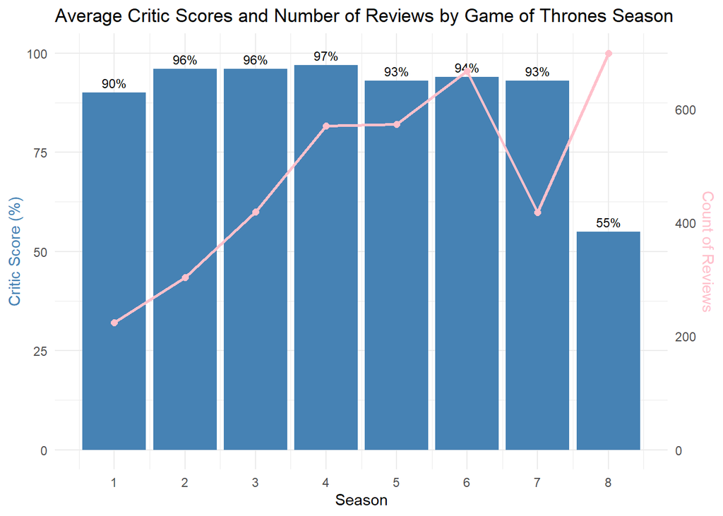